# All Homework Answers

Chen Shuyue

2020-01-02

# HW-2019-09-20

## Question

Use knitr to produce at least 3 examples (texts, figures, tables)

## Answer

- example 1:R code

```r
a = rnorm(50,mean=5)
m = mean(a)
s = sd(a)
c(m-qnorm(0.975)*s/sqrt(50),m+qnorm(0.975)*s/sqrt(50))
```

```
## [1] 4.683491 5.157662
```

This example of R code shows the calculation of 95% confidence interval for the mean of the normal distribution.

- example 2:tables

```r
knitr::kable(head(airquality,n=10))
```

| Ozone | Solar.R | Wind | Temp | Month | Day |
| --- | --- | --- | --- | --- | --- |
| 41 | 190 | 7.4 | 67 | 5 | 1 |
| 36 | 118 | 8.0 | 72 | 5 | 2 |
| 12 | 149 | 12.6 | 74 | 5 | 3 |
| 18 | 313 | 11.5 | 62 | 5 | 4 |
| NA | NA | 14.3 | 56 | 5 | 5 |
| 28 | NA | 14.9 | 66 | 5 | 6 |
| 23 | 299 | 8.6 | 65 | 5 | 7 |
| 19 | 99 | 13.8 | 59 | 5 | 8 |
| 8 | 19 | 20.1 | 61 | 5 | 9 |
| NA | 194 | 8.6 | 69 | 5 | 10 |

This is a table of daily airquality in New York from May 1st to 10th,1973.

- example 3:plots

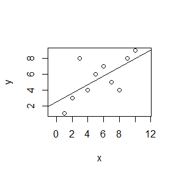

```r
x <- 1:10
y <- c(1,3,8,4,6,7,5,4,8,9)
plot(x,y,asp=1,type="p")
lmout <- lm(y ~ x)
abline(lmout)
```

This example shows the regression curve of x and y.

# HW-2019-09-29

## Question

Exercises 3.4, 3.11, and 3.18 (pages 94-96, Statistical Computating with R).

1. Exercises3.4

The Rayleigh density is $f(x)=\frac{x}{\sigma^{2}} e^{-x^{2} /\left(2 \sigma^{2}\right)},\quad x \geq 0,\sigma>0.$Develop an algorithm to generate random samples from a Rayleigh(σ) distribution. Generate Rayleigh(σ) samples for several choices of σ > 0 and check that the mode of the generated samples is close to the theoretical mode σ (check the histogram).

2. Exercises 3.11

Generate a random sample of size 1000 from a normal location mixture. The components of the mixture have N(0,1) and N(3,1) distributions with mixing probabilities $p_{1}$ and $p_{2}=1-p_{1}$. Graph the histogram of the sample with density superimposed, for $p_{1}=0.75$. Repeat with different values for $p_{1}$ and observe whether the empirical distribution of the mixture appears to be bimodal. Make a conjecture about the values of $p_{1}$ that produce bimodal mixtures.

3. Exercises 3.18

Write a function to generate a random sample from a $W_{d}(\Sigma, n)$(Wishart) distribution for $n>d+1 \geq 1$, based on Bartlett’s decomposition.

## Answer

### 1. Exercises 3.4

- We use acceptance-rejection algorithm to generate random samples from a Rayleigh(σ) distribution.

```r
#function of Rayleigh(σ) distribution.
f<-function(x,s) x/(s^2)*exp(-x^2/(2*s^2))
#function of random samples from a Rayleigh(σ) distribution.
samp4<-function(n,s){
  x<-rnorm(n,s,s)
  y<-runif(n,0,2*dnorm(x,s,s))
  z<-x[y<f(x,s)]
  z
}
```

Then we generate Rayleigh(σ) samples for several choices of σ > 0 and check that the mode of the generated samples is close to the theoretical mode σ (check the histogram).

- for σ=0.5

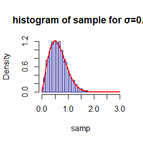

```r
set.seed(11)
samp<- samp4(10000,0.5)[1:5000]
hist(samp, freq=FALSE, breaks=seq(0,3,0.05),border="darkblue",main="histogram of sample for σ=0.5")
curve(f(x,0.5),from=0, to=3, add=T, col="red", lwd=2)
```

- for σ=1

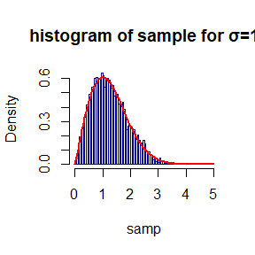

```r
set.seed(10)
samp<- samp4(10000,1)[1:5000]
hist(samp, freq=FALSE, breaks=seq(0,5,0.05),border="darkblue",main="histogram of sample for σ=1")
curve(f(x,1),from=0, to=5, add=T, col="red", lwd=2)
```

- for σ=1.5

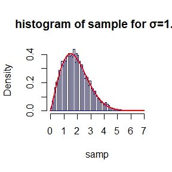

```r
set.seed(14)
samp<- samp4(10000,1.5)[1:5000]
hist(samp, freq=FALSE, breaks=seq(0,7,0.1),border="darkblue",main="histogram of sample for σ=1.5")
curve(f(x,1.5),from=0, to=7, add=T, col="red", lwd=2)
```

- for σ=2

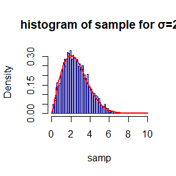

```r
set.seed(22)
samp<- samp4(10000,2)[1:5000]
hist(samp, freq=FALSE, breaks=seq(0,10,0.1),border="darkblue",main="histogram of sample for σ=2")
curve(f(x,2),from=0, to=10, add=T, col="red", lwd=2)
```

From the result,we find that the mode of the generated samples is close to the theoretical mode σ by checking the histogram.

### 2. Exercises 3.11

- function of the random sample of the normal location mixture distribution

```r
samp11 <- function(n,p){
  s <- rbinom(10000, 1, 1-p)
  S <- rnorm(n, 3*s)
  S  }
```

- Graph the histogram of the sample with density superimposed, for $p_{1}=0.75$.

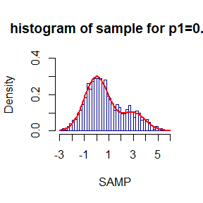

```r
#the real density
f11 <- function(x,p) p*dnorm(x,0)+(1-p)*dnorm(x,3)
#random sample for p=0.75
set.seed(2235)
F11<-samp11(1000,0.75)
SAMP<-F11[F11>-3&F11<6]
#Graph the histogram of the sample with density superimposed
hist(SAMP,freq=FALSE,breaks=seq(-3,6,0.2),ylim=c(0,0.4), axes=FALSE, border="darkblue",main="histogram of sample for p1=0.75")
axis(1,at=(-3):6)
axis(2,at=seq(0,0.4,0.1))
curve(f11(x,p=0.75),from=-3,to=6,add=T,col="red",lwd=2)
```

Then we try different values of $p_{1}$.

- for $p_{1}=0.15$

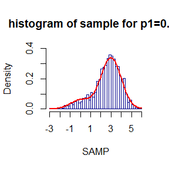

```r
#random sample for p=0.15
set.seed(12)
F11<-samp11(1000,0.15)
SAMP<-F11[F11>-3&F11<6]
#Graph the histogram of the sample with density superimposed
hist(SAMP,freq=FALSE,breaks=seq(-3,6,0.2),ylim=c(0,0.4), axes=FALSE, border="darkblue",main="histogram of sample for p1=0.15")
axis(1,at=(-3):6)
axis(2,at=seq(0,0.4,0.1))
curve(f11(x,p=0.15),from=-3,to=6,add=T,col="red",lwd=2)
```

- for $p_{1}=0.25$

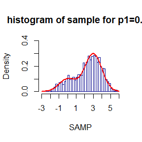

```r
#random sample for p=0.25
set.seed(2334)
F11<-samp11(1000,0.25)
SAMP<-F11[F11>-3&F11<6]
#Graph the histogram of the sample with density superimposed
hist(SAMP,freq=FALSE,breaks=seq(-3,6,0.2),ylim=c(0,0.4), axes=FALSE, border="darkblue",main="histogram of sample for p1=0.25")
axis(1,at=(-3):6)
axis(2,at=seq(0,0.4,0.1))
curve(f11(x,p=0.25),from=-3,to=6,add=T,col="red",lwd=2)
```

- for $p_{1}=0.5$

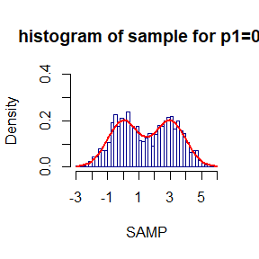

```r
#random sample for p=0.5
set.seed(2346)
F11<-samp11(1000,0.5)
SAMP<-F11[F11>-3&F11<6]
#Graph the histogram of the sample with density superimposed
hist(SAMP,freq=FALSE,breaks=seq(-3,6,0.2),ylim=c(0,0.4), axes=FALSE, border="darkblue",main="histogram of sample for p1=0.5")
axis(1,at=(-3):6)
axis(2,at=seq(0,0.4,0.1))
curve(f11(x,p=0.5),from=-3,to=6,add=T,col="red",lwd=2)
```

- for $p_{1}=0.65$

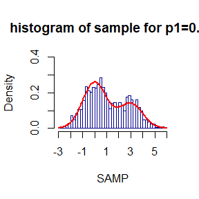

```r
#random sample for p=0.65
set.seed(23)
F11<-samp11(1000,0.65)
SAMP<-F11[F11>-3&F11<6]
#Graph the histogram of the sample with density superimposed
hist(SAMP,freq=FALSE,breaks=seq(-3,6,0.2),ylim=c(0,0.4), axes=FALSE, border="darkblue",main="histogram of sample for p1=0.65")
axis(1,at=(-3):6)
axis(2,at=seq(0,0.4,0.1))
curve(f11(x,p=0.65),from=-3,to=6,add=T,col="red",lwd=2)
```

- for $p_{1}=0.85$

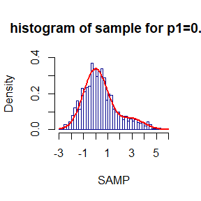

```r
#random sample for p=0.85
set.seed(234)
F11<-samp11(1000,0.85)
SAMP<-F11[F11>-3&F11<6]
#Graph the histogram of the sample with density superimposed
hist(SAMP,freq=FALSE,breaks=seq(-3,6,0.2),ylim=c(0,0.4), axes=FALSE, border="darkblue",main="histogram of sample for p1=0.85")
axis(1,at=(-3):6)
axis(2,at=seq(0,0.4,0.1))
curve(f11(x,p=0.85),from=-3,to=6,add=T,col="red",lwd=2)
```

- conjecture about the values of $p_{1}$ that produce bimodal mixtures

### 3. Exercises 3.18

- function of the random sample from a $W_{d}(\Sigma, n)$ distribution.

```r
wishart<-function(sig,d,n){
  T<-matrix(0,nrow=d,ncol=d)
  for(i in 1:d){
    for(j in 1:d){
      if(i>j) T[i,j]<-rnorm(1,0,1)
      else if(i==j) T[i,j]<-sqrt(rchisq(1,df=n-i+1))
    }
  }
  A<-T%*%t(T)  #Wd(Id,n) distribution
  L<-t(chol(sig))  #lower triangular
  W<-L%*%A%*%t(L)  #Bartlett’s decomposition
  W
}
```

So $wishart$ is the function of the random sample from a $W_{d}(\Sigma, n)$ distribution.

# HW-2019-10-11

## Question

Exercises 5.1, 5.10, and 5.15 (pages 149-151, Statistical Computating with R).

## Answer

### 1. Exercises 5.1

Compute a Monte Carlo estimate of $\int_{0}^{\pi / 3} \sin t d t$ and compare your estimate with the exact value of the integral.

$\int_{0}^{\pi / 3} \sin t d t=\frac{\pi}{3} \int_{0}^{\frac{\pi}{3}} \sin t \cdot \frac{3}{\pi} d t=\frac{\pi}{3} E_{X}[\sin X], X \sim U\left[0, \frac{\pi}{3}\right]$,so $g(x)=\frac{\pi}{3}\sin x$.

The exact value of the integral is$\int_{0}^{\pi / 3} \sin t d t=1-cos(\pi/3)=0.5$

```r
set.seed(124)
m<-10000
x<-runif(m,min=0,max=pi/3)
theta.hat<-mean(sin(x))*(pi/3)
print(c(theta.hat,0.5))
```

```
## [1] 0.5012242 0.5000000
```

The result is very close to the exact value of the integral.

### 2.Exercises 5.10

Use Monte Carlo integration with antithetic variables to estimate $\int_{0}^{1}\frac{e^{-x}}{1+x^{2}} d x$ and find the approximate reduction in variance as a percentage of the variance without variance reduction.

$\int_{0}^{1}\frac{e^{-x}}{1+x^{2}} d x=E_{X}[\frac{e^{-x}}{1+x^{2}}],X \sim U\left[0,1\right]$,$U$ and $1-U$ has the same distribution and negatively correlated.

```r
MC<-function(R=10000,antithetic=TRUE){
  u<-runif(R/2)
  if(!antithetic) v<-runif(R/2)
  else v<-1-u
  u<-c(u,v)
  g<-mean(exp(-u)/(1+u^2))
  g
}
set.seed(1234)
theta.hat<-MC(anti=TRUE)
#true value of the integral
f<-function(x) exp(-x)/(1+x^2)
theta<-integrate(f,0,1)
print(c(theta.hat,theta$value))
```

```
## [1] 0.5246322 0.5247971
```

```r
#percentage of variance reduction
m<-1000
MC1<-MC2<-numeric(m)
for(i in 1:m){
  MC1[i]<-MC(anti=FALSE)
  MC2[i]<-MC(anti=TRUE)
}
print(c(sd(MC1),sd(MC2),(sd(MC1)-sd(MC2))/sd(MC1)))
```

```
## [1] 0.0023969362 0.0004560375 0.8097414719
```

### 3.Exercises 5.15

Obtain the stratified importance sampling estimate in Example 5.13 and compare it with the result of Example 5.10.

In Example 5.10,we want to estimate $\int_{0}^{1}\frac{e^{-x}}{1+x^{2}} d x$.We choose the importance function $f_{3}(x)=e^{-x} /\left(1-e^{-1}\right), 0<x<1$.Now divide the interval (0,1) into five subintervals,$I_{j}=\left\{x: a_{j-1} \leq x<a_{j}\right\}$.Then on the $j^{th}$ subinterval variables are generated from the density $\frac{5e^{-x}}{1-e^{-1}},a_{j-1}<x<a_{j}$.

```r
m<-10000
k<-5
r<-m/k
N<-1000
T2<-numeric(k)
est<-matrix(0,N,2)
a<-numeric(k+1)
for(j in 1:(k+1)) a[j]<--log(1-(j-1)/k*(1-exp(-1)))
set.seed(1235)
for(i in 1:N){
  u1<-runif(m)
  x<--log(1-u1*(1-exp(-1)))
  fg<-(1-exp(-1))/(1+x^2)
  est[i,1]<-mean(fg)
  for(j in 1:k){
    u2<-runif(r)
    x<--log(exp(-a[j])-u2*(1-exp(-1))*1/5)
    fg<-1/5*(1-exp(-1))/(1+x^2)
    T2[j]<-mean(fg)*5
  }
  est[i,2]<-mean(T2)
}
estimate<-apply(est,2,mean)
sd<-apply(est,2,sd)
print(rbind(estimate,sd))
```

```
##                 [,1]         [,2]
## estimate 0.524759179 0.5247970375
## sd       0.000961924 0.0001971763
```

Compared with the result of Example 5.10,it is obvious that the variance is reduced after stratified.

# HW-2019-10-18

## Question

Exercises 6.5 and 6.6 (pages 180, Statistical Computating with R).

## Answer

### 1. Exercises 6.5

Suppose a 95% symmetric t-interval is applied to estimate a mean, but the sample data are non-normal. Then the probability that the confidence interval covers the mean is not necessarily equal to 0.95. Use a Monte Carlo experiment to estimate the coverage probability of the t-interval for random samples of $\chi^{2}(2)$ data with sample size $n = 20$. Compare your t-interval results with the simulation results in Example 6.4. (The t-interval should be more robust to departures from normality than the interval for variance.)

$\chi^{2}(2)$ has mean 2.The estimation of the coverage probability of the t-interval for random samples of $\chi^{2}(2)$ data is shown as below.If the sample data are normal,the 95% confidence interval is $(\bar{X}-\frac{1}{\sqrt{n}}t_{n-1}(0.975)se(X),\bar{X}+\frac{1}{\sqrt{n}}t_{n-1}(0.975)se(X))$.We still use this confidence interval when the sample data are non-normal.

```r
n <- 20
alpha <- 0.05
CI1 <- replicate(1000, expr = {
x <- rchisq(n, df = 2)
mean(x)-qt(1-alpha/2, df = n-1)*sd(x)/sqrt(n)
} )
CI2 <- replicate(1000, expr = {
x <- rchisq(n, df = 2)
mean(x)+qt(1-alpha/2, df = n-1)*sd(x)/sqrt(n)
} )
#The estimation of the coverage probability
mean(CI1<2&CI2>2)
```

```
## [1] 0.908
```

The simulation results in Example 6.4 when the sample data are non-normal.

```r
n <- 20
alpha <- .05
UCL <- replicate(1000, expr = {
x <- rchisq(n, df = 2)
(n-1) * var(x) / qchisq(alpha, df=n-1)
} )
mean(UCL>4)
```

```
## [1] 0.788
```

Compare the t-interval results with the simulation results in Example 6.4.

```r
print(c(mean(CI1<2&CI2>2),mean(UCL>4)))
```

```
## [1] 0.908 0.788
```

We can find that the t-interval is more robust to departures from normality than the interval for variance.

### 2. Exercises 6.6

Estimate the 0.025, 0.05, 0.95, and 0.975 quantiles of the skewness $\sqrt{b_{1}}$ under normality by a Monte Carlo experiment. Compute the standard error of the estimates from (2.14) using the normal approximation for the density (with exact variance formula). Compare the estimated quantiles with the quantiles of the large sample approximation $\sqrt{b_{1}} \approx N(0,6 / n)$.

The skewness $\sqrt{b_{1}}$ is defined as $\sqrt{b_{1}}=\frac{\frac{1}{n} \sum_{i=1}^{n}\left(X_{i}-\bar{X}\right)^{3}}{\left(\frac{1}{n} \sum_{i=1}^{n}\left(X_{i}-\bar{X}\right)^{2}\right)^{3 / 2}}$.

From (2.14) we know that the variance of the q sample quantile is $\operatorname{Var}\left(\hat{x}_{q}\right)=\frac{q(1-q)}{n f\left(x_{q}\right)^{2}}$,where f is the density of the sampled distribution.For finite samples,the normal approximation for the density is $N(0,\frac{6(n-2)}{(n+1)(n+3)})$.

```r
m<-1000
n<-1000
q<-c(0.025,0.05,0.95,0.975)
skew <- matrix(0,ncol=4,nrow=m)
for(j in 1:m){
  a<-numeric(n)
  for(i in 1:n){
    x<-rnorm(n)
    a[i]<-mean((x-mean(x))^3)/(var(x))^(3/2)
  }
  skew[j,1]<-quantile(a,q[1])
  skew[j,2]<-quantile(a,q[2])
  skew[j,3]<-quantile(a,q[3])
  skew[j,4]<-quantile(a,q[4])
}
#estimated quantiles
sq_b1<-apply(skew,2,mean)
#quantiles of the large sample approximation
b<-numeric(4)
for(i in 1:4){
  b[i]<-qnorm(q[i],0,sqrt(6/m))
}
#the standard error of the estimates
se<-numeric(4)
for(i in 1:4){
  se[i]<-sqrt((1/m)*q[i]*(1-q[i])/dnorm(b[i],0,sqrt(6*(m-2)/((m+1)*(m+3)))))
}
print(se)
```

```
## [1] 0.005708130 0.005988196 0.005988196 0.005708130
```

Compare the estimated quantiles with the quantiles of the large sample approximation.

```r
a<-rbind(sq_b1,b)
rownames(a)<-c("estimated quantiles","quantiles of approximation")
colnames(a)<-q
print(a)
```

```
##                                 0.025       0.05      0.95     0.975
## estimated quantiles        -0.1505601 -0.1261659 0.1264742 0.1506280
## quantiles of approximation -0.1518182 -0.1274098 0.1274098 0.1518182
```

The result is very close.

# HW-2019-11-01

## Question

Exercises 6.7 and 6.A and discussion (pages 180-181, Statistical Computating with R).

## Answer

### 1. Exercises 6.7

Estimate the power of the skewness test of normality against symmetric Beta(α, α) distributions and comment on the results. Are the results different for heavy-tailed symmetric alternatives such as t(ν)?

First estimate the power of the skewness test of normality against symmetric Beta(α, α) distributions.

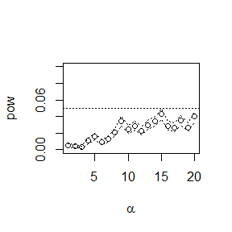

```r
#function to compute the sample skewness statistic
sk <- function(x) {
  #computes the sample skewness coeff
  m3 <- mean((x - mean(x))^3)
  m2 <- mean((x - mean(x))^2)
  return( m3 / m2^1.5 )
}

n <- 50
m <- 1000
alpha<-1:20
N <- length(alpha)
pow <- numeric(N)
#critical value for the skewness test
cv <- qnorm(0.975,0,sqrt(6*(n-2)/((n+1)*(n+3))))
#Power of the skewness test of normality
for (j in 1:N) {
   a <- alpha[j]
   sktests <- numeric(m)
   for (i in 1:m) {
       x <- rbeta(n,a,a)
       sktests[i] <- as.integer(abs(sk(x)) >= cv)
   }
   pow[j] <- mean(sktests)
}
#plot power vs alpha
plot(alpha, pow, type = "b",xlab = bquote(alpha), ylim = c(0,0.1))
abline(h = 0.05, lty = 3)
se <- sqrt(pow * (1-pow) / m) #add standard errors
lines(alpha, pow+se, lty = 3)
lines(alpha, pow-se, lty = 3)
```

From the plot,we can find that the power of the skewness test of normality against symmetric Beta(α, α) distributions is very small,even smaller than 0.05.So we can say that symmetric Beta(α, α) distributions are not in the alternative hypothesis.

Then we estimate the power of the skewness test of normality against heavy-tailed symmetric alternatives such as t(ν).

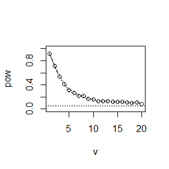

```r
n <- 50
m <- 1000
v<-1:20
N <- length(v)
pow <- numeric(N)
#critical value for the skewness test
cv <- qnorm(0.975,0,sqrt(6*(n-2)/((n+1)*(n+3))))
#Power of the skewness test of normality
for (j in 1:N) { #for each v
   a <- v[j]
   sktests <- numeric(m)
   for (i in 1:m) { #for each replicate
       x <- rt(n,a)
       sktests[i] <- as.integer(abs(sk(x)) >= cv)
   }
   pow[j] <- mean(sktests)
}
#plot power vs v
plot(v, pow, type = "b",xlab = bquote(v), ylim = c(0,1))
abline(h = 0.05, lty = 3)
se <- sqrt(pow * (1-pow) / m) #add standard errors
lines(alpha, pow+se, lty = 3)
lines(alpha, pow-se, lty = 3)
```

From the plot we can find that the power of the skewness test of normality against t(ν) is much bigger than that of Beta(α, α).So comparing two results,the heavy-tailed symmetric distributions are in the alternative hypothesis,the Beta(α, α) is not suitable to this test.

### 2. Exercises 6.A

Use Monte Carlo simulation to investigate whether the empirical Type I error rate of the t-test is approximately equal to the nominal significance level α, when the sampled population is non-normal. The t-test is robust to mild departures from normality. Discuss the simulation results for the cases where the sampled population is (i) $\chi^{2}(1)$, (ii) Uniform(0,2), and (iii) Exponential(rate=1). In each case, test $H_{0}:\mu=\mu_{0}$ vs $H_{0}: \mu \neq \mu_{0}$, where $\mu_{0}$ is the mean of $\chi^{2}(1)$, Uniform(0,2), and Exponential(1), respectively.

- $\chi^{2}(1)$

```r
n <- c(10,20,40,50,80,100)
N<-length(n)
t1<-numeric(N)
se.hat<-numeric(N)
alpha <- 0.05
mu0 <- 1
m <- 10000 #number of replicates
for (i in 1:N) {
  l<-n[i]
  p<-numeric(m)
  for (j in 1:m) {
        x <- rchisq(l, 1)
        ttest <- t.test(x,  mu = mu0)
        p[j] <- ttest$p.value
   }
  t1[i] <- mean(p < alpha)
  se.hat[i] <- sqrt(t1[i] * (1 - t1[i]) / m)
}
X<-rbind(t1,se.hat)
colnames(X)<-c(10,20,40,50,80,100)
print(X)
```

```
##                 10          20          40          50          80         100
## t1     0.141700000 0.108400000 0.081400000 0.075500000 0.070300000 0.062000000
## se.hat 0.003487422 0.003108849 0.002734484 0.002641964 0.002556519 0.002411556
```

- Uniform(0,2)

```r
n <- c(10,20,40,50,80,100)
N<-length(n)
t1<-numeric(N)
se.hat<-numeric(N)
alpha <- 0.05
mu0 <- 1
m <- 10000 #number of replicates
for (i in 1:N) {
  l<-n[i]
  p<-numeric(m)
  for (j in 1:m) {
        x <- runif(l,0,2)
        ttest <- t.test(x,  mu = mu0)
        p[j] <- ttest$p.value
   }
  t1[i] <- mean(p < alpha)
  se.hat[i] <- sqrt(t1[i] * (1 - t1[i]) / m)
}
X<-rbind(t1,se.hat)
colnames(X)<-c(10,20,40,50,80,100)
print(X)
```

```
##                 10          20          40          50          80         100
## t1     0.051900000 0.050100000 0.049700000 0.048700000 0.050200000 0.050600000
## se.hat 0.002218251 0.002181513 0.002173244 0.002152401 0.002183574 0.002191795
```

From the result,we can see that the empirical Type I error rate of the Uniform(0,2) is close to the nominal significance level α=0.05.

- Exponential(1)

```r
n <- c(10,20,40,50,80,100)
N<-length(n)
t1<-numeric(N)
se.hat<-numeric(N)
alpha <- 0.05
mu0 <- 1
m <- 10000 #number of replicates
for (i in 1:N) {
  l<-n[i]
  p<-numeric(m)
  for (j in 1:m) {
        x <- rexp(l,1)
        ttest <- t.test(x, mu = mu0)
        p[j] <- ttest$p.value
   }
  t1[i] <- mean(p < alpha)
  se.hat[i] <- sqrt(t1[i] * (1 - t1[i]) / m)
}
X<-rbind(t1,se.hat)
colnames(X)<-c(10,20,40,50,80,100)
print(X)
```

```
##                 10         20          40          50          80         100
## t1     0.101200000 0.08210000 0.067600000 0.062100000 0.062000000 0.058700000
## se.hat 0.003015934 0.00274517 0.002510582 0.002413371 0.002411556 0.002350624
```

### 3.Discussion

If we obtain the powers for two methods under a particular simulation setting with 10000 experiments:say,0.651 for one method and 0.676 for another method.Can we say the powes are different at 0.05 level?

- What is the corresponding hypothesis test problem?

$H_{0}:pw_{1}=pw_{2}$,$pw_{1},pw_{2}$ represents the powers for two methods under a particular simulation.

- What test should we use?

We should use McNemar test.It’s about two test on the same sample.

```r
X<-c(6510,3490,3240,6760)
dim(X)<-c(2,2)
mcnemar.test(X,correct=FALSE)
```

```
##
##  McNemar's Chi-squared test
##
## data:  X
## McNemar's chi-squared = 9.2868, df = 1, p-value = 0.002308
```

p-value<0.05,so we think that the powers are different.

- What information is needed to test your hypothesis?

The samples should be the same,the method is applied to the same population.